# Gender Wage Gap Analysis

Author: Aileen Gui

Created: May 2020

```python
from IPython.display import display
from IPython.display import HTML
import IPython.core.display as di # Example: di.display_html('<h3>%s:</h3>' % str, raw=True)

# This line will hide code by default when the notebook is exported as HTML
di.display_html('<script>jQuery(function() {if (jQuery("body.notebook_app").length == 0) { jQuery(".input_area").toggle(); jQuery(".prompt").toggle();}});</script>', raw=True)

# This line will add a button to toggle visibility of code blocks, for use with the HTML export version
di.display_html('''<button onclick="jQuery('.input_area').toggle(); jQuery('.prompt').toggle();">Toggle code</button>''', raw=True)

#Source: https://stackoverflow.com/questions/27934885/how-to-hide-code-from-cells-in-ipython-notebook-visualized-with-nbviewer
```

```python
#Importing libraries. The same will be used throughout the article.
import numpy as np
import pandas as pd
import random
import matplotlib.pyplot as plt
%matplotlib inline
from matplotlib.pylab import rcParams
import matplotlib
#misc packages
import itertools
#plotting
import seaborn as sns
from mpl_toolkits import mplot3d
plt.rcParams['figure.figsize'] = (5,5)
#3d plotting at the end
import plotly.express as px
from IPython.display import Image
#stat analysis
from scipy import stats
from scipy import special
import statsmodels.api as sm
import statsmodels.formula.api as smf
import statsmodels
#Reminder on how to install packages
import sys
!{sys.executable} -m pip install Stargazer
from stargazer.stargazer import Stargazer
from IPython.core.display import HTML
from statsmodels.iolib.summary2 import summary_col
from Oaxaca import Oaxaca
```

```
You are using pip version 9.0.3, however version 20.1.1 is available.
```

```python
#importing datasets
dd = pd.read_csv("project2020_dd.csv")
```

# Data

"dd": This dataset from Portugal employment data has 1 record per person for 16,969 observations (10,575 for men, 6,394 for women). Each person is observed in 6 consecutive years. The timing convention for the measurement of all data is that period 0 is the 4th year of observation. Therefore, we observe 3 years before year 0 (years l1, l2, l3, "l" for lagged) and 2 years after year 0 (year p1 and p2, "p" for plus). The data are in "event study" format so year 0 is the first year of each person on a new job. In years -3, -2, and -1, they worked on "job 1" and in years 0,1, and 2 they worked on "job 2". The following variables are available and hold information about period 0

- age (as of year 0)
- educ (= years of education, does not change over time)
- female
- exp = measure of # of years since the person completed school, sometimes called "potential experience"

The following additional wage information is available for other periods:

- yp1 = wage in year 1
- yp2 = wage in year 2
- yl1 = wage in year -1
- yl2 = wage in year -2
- yl3 = wage in year -3

In addition we observe the mean wages of other workers on the first job and the second job:

- owage1 = mean log wage of other workers at the first job (held in period -3,-2,-1)
- owage2 = mean log wage of other workers at the second job (held in period 0,1,2)

# Comparing Initial Characteristics

Goal: compare the characteristics and wages of male and female workers, focusing on period 0

Format of the table:

- column 1 = characteristics for all workers
- column 2 = characteristics for female workers
- column 3 = characteristics for male workers
- column 4 = test statistic comparing females and males (t test)

Main characteristics of interest are:

- education: note that education takes on only 4 values: 6,9,12, and 16 corresponding to elementary schooling; some high school; completed high school and university
- age: note that the sample excludes people who are over 52 years old
- log of real hourly wage (y)
- mean log real hour wage for co-workers as of period 0 (owage2)

```python
#Table 1
#cleaning datasets
ddsubset = dd[['y', 'educ', 'age', 'owage2']]
dd_subset = pd.DataFrame(ddsubset.mean()).rename(columns = {0: "All Workers"})

dd_allfemale = dd[dd["female"] == 1][['y', 'educ', 'age', 'owage2']]
ddallfemale = pd.DataFrame(dd_allfemale.mean()).rename(columns = {0: "Female Only"})

dd_allmale = dd[dd["female"] == 0][['y', 'educ', 'age', 'owage2']]
ddallmale = pd.DataFrame(dd_allmale.mean()).rename(columns = {0: "Male Only"})
```

```python
#Table 1
#adding t-test column
horizontal_stack = pd.concat([dd_subset, ddallfemale, ddallmale], axis=1, sort = False)
eductstat = stats.ttest_ind(dd_allfemale['educ'], dd_allmale['educ'], axis = 0, equal_var = True, nan_policy = 'omit')[0]
agetstat = stats.ttest_ind(dd_allfemale['age'], dd_allmale['age'], axis = 0, equal_var = True, nan_policy = 'omit')[0]
ytstat = stats.ttest_ind(dd_allfemale['y'], dd_allmale['y'], axis = 0, equal_var = True, nan_policy = 'omit')[0]
owage2tstat = stats.ttest_ind(dd_allfemale['owage2'], dd_allmale['owage2'], axis = 0, equal_var = True, nan_policy = 'omit')[0]
compare = [ytstat, eductstat, agetstat, owage2tstat]
horizontal_stack['Male-Female Comparison'] = compare
horizontal_stack.style.set_caption("Table 1: Worker Characteristics")
```

Table 1: Worker Characteristics

|  | All Workers | Female Only | Male Only | Male-Female Comparison |
| --- | --- | --- | --- | --- |
| y | 1.78792 | 1.65804 | 1.86645 | -20.6416 |
| educ | 10.4841 | 10.8348 | 10.2721 | 9.93492 |
| age | 33.5589 | 33.5344 | 33.5737 | -0.435744 |
| owage2 | 1.69207 | 1.63779 | 1.72489 | -11.8401 |

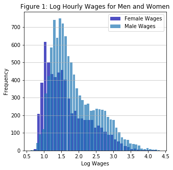

```python
#Figure 1
#plotting the smoothed histograms of log hourly wages for men and women on one figure

plt.grid(axis='y', alpha=0.75)
plt.hist(x = dd_allfemale['y'], bins = 'auto', color='#0504aa', alpha=0.7, rwidth = 0.85, label='Female Wages')
plt.hist(x = dd_allmale['y'], bins = 'auto', alpha=0.7, rwidth = 0.85, label='Male Wages')
plt.legend(loc='upper right')
plt.xlabel('Log Wages')
plt.ylabel('Frequency')
plt.title('Figure 1: Log Hourly Wages for Men and Women')
```

**What are the main differences between men and women in period 0?**

The main difference lies in the peaks of mean log hourly wages, mean log hourly wages of coworkers, and education as seen in Table 1 "Male-Female Comparison" column. This column shows the t-statistics calculated for the differences between males and females, and t-statistics for the three variables mentioned are all greater than 1.96 in absolute terms. This means that the differences for men and women in mean log hourly wages, mean log hourly wages of coworkers, and education are all statistically significant in period 0. Shown in the figure "Log Hourly Wages for Men and Women", we see that the histogram for men looks almost like a copy of the histogram for women but shifted to the right, meaning that, on average, men make higher hourly wages than women in this dataset. We see this belief confirmed in Table 1 as well, where the coefficient relating gender to log wages is high for men than it is for women.

# Further Visualization of Gaps

Goal: fit a series of standard wage models for wages in period 0 and construct Oaxaca decompositions of the wage gap between men and women

We will start by fitting 2 models using the pooled data for men and women:

```python
#first model
q2data1 = dd[['female']]
q2data1 = sm.add_constant(q2data1)
yvar = dd['y']
q2model1 = sm.OLS(yvar, q2data1).fit()
#second model
dd['exp_cubed'] = pow(dd['exp'], 3)
q2data2 = dd[['educ', 'exp_cubed', 'female']]
q2data2 = sm.add_constant(q2data2)
q2model2 = sm.OLS(yvar, q2data2).fit()
```

Next, we will fit separate models for men and women that include a constant, education, and a cubic in experience. Using all 4 models, we will construct standard Oaxaca decompositions with both alternatives (2-fold, 3-fold).

```python
#third model
femaleonly = dd[dd["female"] == 1][['educ', 'exp_cubed']]
maleonly = dd[dd["female"] == 0][['educ', 'exp_cubed']]
femaleonly = sm.add_constant(femaleonly)
maleonly = sm.add_constant(maleonly)
yvarfemale = dd[dd["female"] ==1]['y']
femaleonlymodel = sm.OLS(yvarfemale, femaleonly).fit()
#fourth model
yvarmale = dd[dd["female"] ==0]['y']
maleonlymodel = sm.OLS(yvarmale, maleonly).fit()
```

```python
#Table representation of results
stargazer = Stargazer([q2model1, q2model2, femaleonlymodel, maleonlymodel])
stargazer.title("Table 2: Examining Mean Log Wage Characteristics")
stargazer.custom_columns(["Entire Sample1", "Entire Sample2", "Female Only", "Male Only"], [1,1,1,1])
HTML(stargazer.render_html())
```

Table 2: Examining Mean Log Wage Characteristics

|  | *Dependent variable:* |  |  |  |
| --- | --- | --- | --- | --- |
|  | Entire Sample1 | Entire Sample2 | Female Only | Male Only |
|  | (1) | (2) | (3) | (4) |
| const | 1.866*** | 0.291*** | 0.011 | 0.292*** |
|  | (0.006) | (0.013) | (0.021) | (0.017) |
| educ |  | 0.14*** | 0.142*** | 0.139*** |
|  |  | (0.001) | (0.002) | (0.001) |
| exp_cubed |  | 0.0*** | 0.0*** | 0.0*** |
|  |  | (0.0) | (0.0) | (0.0) |
| female | -0.208*** | -0.28*** |  |  |
|  | (0.01) | (0.007) |  |  |
| Observations | 16969.0 | 16969.0 | 6394.0 | 10575.0 |
| R<sup>2</sup> | 0.024 | 0.541 | 0.57 | 0.507 |
| Adjusted R<sup>2</sup> | 0.024 | 0.541 | 0.57 | 0.507 |
| Residual Std. Error | 0.637(df = 16967.0) | 0.437(df = 16965.0) | 0.409(df = 6391.0) | 0.453(df = 10572.0) |
| F Statistic | 426.076***(df = 1.0; 16967.0) | 6659.426***(df = 3.0; 16965.0) | 4236.974***(df = 2.0; 6391.0) | 5436.769***(df = 2.0; 10572.0) |
| Note: | *p<0.1; **p<0.05; ***p<0.01 |  |  |  |

```
These are the attempted split values: Int64Index([0, 1], dtype='int64')
Unexplained Effect: 0.27977
Explained Effect: -0.07136
Gap: 0.2084
```

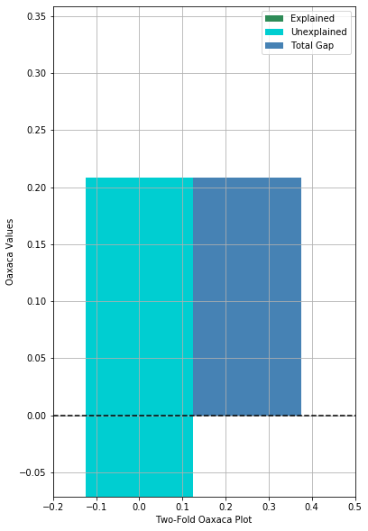

```python
#Two-fold oaxaca decomposition
oaxacadata = dd[['y', 'educ', 'exp_cubed', 'female']]
model = Oaxaca(oaxacadata, by = 'female', endo = 'y')
model.fit(two_fold = True, three_fold = False)
model.plot(plt_type = 2)
```

```
These are the attempted split values: Int64Index([0, 1], dtype='int64')
Characteristic Effect: -0.0731
Coefficent Effect: 0.2786
Interaction Effect: 0.00291
Gap: 0.2084
```

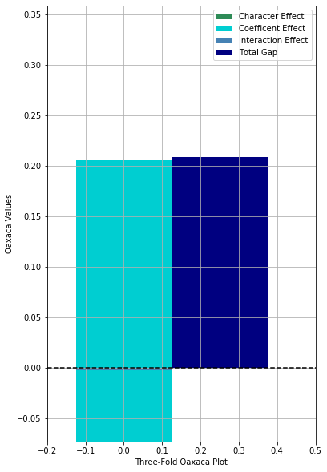

```python
#Three-fold oaxaca decomposition
model1 = Oaxaca(oaxacadata, "female", 'y')
model1.fit(two_fold = False, three_fold = True)
model1.plot(3)
```

# Introducing Coworker Wages as a Control Variable

Goal: examine the effect of a new control variable, which is the mean log wage of a person's co-workers (the variable owage2)

First, we will fit 2 models using the pooled data for men and women:

1. including only a constant, female dummy, and owage2
2. including a constant, education, a cubic in experience, a female dummy, and owage2

```python
#first model
data3 = dd[['female', 'owage2']]
data3 = sm.add_constant(data3)
yvar = dd['y']
model3 = sm.OLS(yvar, data3).fit()
```

```python
#second model
data4 = dd[['educ', 'exp_cubed', 'female', 'owage2']]
data4 = sm.add_constant(data4)
model4 = sm.OLS(yvar, data4).fit()
```

Next, we will fit separate models for men and women that include a constant, education, and a cubic in experience, and owage2. Using these models, we will conduct a pair of new decompositions that accounts for the effect of higher-wage coworkers, constructing both decompositions (2-fold, 3-fold).

```python
#men only
maleonly3 = dd[dd["female"] == 0][['educ', 'exp_cubed', 'owage2']]
maleonly3 = sm.add_constant(maleonly3)
maleonlymodel3 = sm.OLS(yvarmale, maleonly3).fit()
```

```python
#women only
femaleonly3 = dd[dd["female"] == 1][['educ', 'exp_cubed', 'owage2']]
femaleonly3 = sm.add_constant(femaleonly3)
yvarfemale = dd[dd["female"] == 1]['y']
femaleonlymodel3 = sm.OLS(yvarfemale, femaleonly3).fit()
```

```python
#Table representation of results
stargazer3 = Stargazer([model3, model4, femaleonlymodel3, maleonlymodel3])
stargazer3.custom_columns(["Entire Sample1", "Entire Sample2", "Female Only", "Male Only"], [1,1,1,1])
stargazer3.title("Table 3: Examining Mean Log Wage Characteristics")
HTML(stargazer3.render_html())
```

Table 3: Examining Mean Log Wage Characteristics

|  | *Dependent variable:* |  |  |  |
| --- | --- | --- | --- | --- |
|  | Entire Sample1 | Entire Sample2 | Female Only | Male Only |
|  | (1) | (2) | (3) | (4) |
| const | 0.131*** | -0.28*** | -0.361*** | -0.355*** |
|  | (0.013) | (0.013) | (0.019) | (0.017) |
| educ |  | 0.089*** | 0.087*** | 0.09*** |
|  |  | (0.001) | (0.002) | (0.001) |
| exp_cubed |  | 0.0*** | 0.0*** | 0.0*** |
|  |  | (0.0) | (0.0) | (0.0) |
| female | -0.121*** | -0.196*** |  |  |
|  | (0.007) | (0.006) |  |  |
| owage2 | 1.006*** | 0.651*** | 0.616*** | 0.678*** |
|  | (0.007) | (0.007) | (0.011) | (0.009) |
| Observations | 16969.0 | 16969.0 | 6394.0 | 10575.0 |
| R<sup>2</sup> | 0.549 | 0.688 | 0.708 | 0.667 |
| Adjusted R<sup>2</sup> | 0.548 | 0.688 | 0.708 | 0.667 |
| Residual Std. Error | 0.434(df = 16966.0) | 0.36(df = 16964.0) | 0.337(df = 6390.0) | 0.372(df = 10571.0) |
| F Statistic | 10306.293***(df = 2.0; 16966.0) | 9363.479***(df = 4.0; 16964.0) | 5166.352***(df = 3.0; 6390.0) | 7064.69***(df = 3.0; 10571.0) |
| Note: | *p<0.1; **p<0.05; ***p<0.01 |  |  |  |

```
These are the attempted split values: Int64Index([0, 1], dtype='int64')
Unexplained Effect: 0.19582
Explained Effect: 0.01259
Gap: 0.2084
```

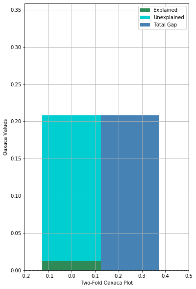

```python
#Two-fold decomposition
oaxaca2data = dd[['y', 'educ', 'exp_cubed', 'female', 'owage2']]
oaxacamodel2 = Oaxaca(oaxaca2data, by = 'female', endo = 'y')
oaxacamodel2.fit(two_fold = True, three_fold = False)
oaxacamodel2.plot(plt_type = 2)
```

```
Characteristic Effect: 0.00918
Coefficent Effect: 0.1932
Interaction Effect: 0.00602
Gap: 0.2084
```

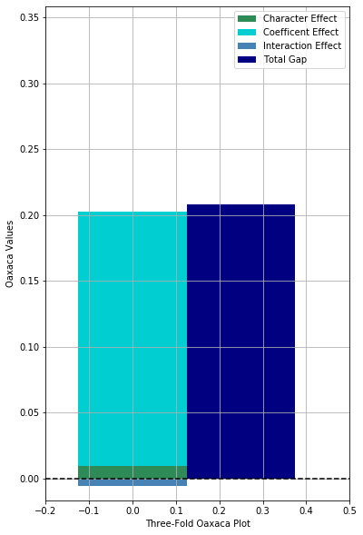

```python
#Three-fold decomposition
oaxacamodel2.fit(two_fold = False, three_fold = True)
oaxacamodel2.plot(3)
```

There are alternative interpretations of the effect of working with highly paid coworkers. 2 possible explanations we will explore are:

- Model 1: getting a job with high paid co-workers is largely a matter of good luck or connections, and men have better connections, or search harder to find higher paid coworkers jobs.
- Model 2: getting a job with highly paid co-workers is only possible for workers who have high levels of cognitive skills or ambition, which is not measured in our data but potentially varies by gender.

Controlling for owage2 makes quite a difference to the gender gap. The wage effect of working with highly paid coworkers in quite large, and in the models that allow different returns by gender, the effect is smaller for woman than men. In this oaxaca decomposition, we've included another variable from the one done in question 1.2. We've included the pay of co-workers, and this has led to a significant dent in explaining the difference in wages between men and women. Now, the unexplained effect has decreased to 0.19582

One reason having higher paid coworkers may affect the gender pay gap is given in model 1: higher paid coworkers are a result of good connections, and men may have better connections or search harder to find jobs with higher paid coworkers. This might be plausible if men are on average more involved in extracurricular activities that create connections, network more, or if male-dominated industries coincide with higher-paying industries (such as investment banking or software engineering).

Another reason having higher paid coworkers may affect the gender pay gap is due to omitted variable bias as mentioned in model 2. Perhaps men are more likely to have higher paid co-workers because those jobs are reserved for those with high levels of cognitive ability or ambition, assuming these traits vary by gender. A common argument in favor of this model can be seen with negotiation confidence. For instance, if men are more likely to be assertive when asking for raises or negotiating work-contract terms. If men are, on average, more ambitious than women, then men might ask for promotions more frequently or engage in strategic networking more frequently.

# Why Coworker Wages Matter

Using the fact that we have job changers in the data, we will conduct some event studies of how wage changes as people move between jobs with higher and lower paid coworkers.

#### Setup

- Find the terciles of owage1
- Classify all the first jobs (held in periods -3, -2, and -1) into 3 groups based on the tercile of owage1
- Find the terciles of owage2
- Classify all second jobs (held in periods 0, 1, 2) into 3 groups
- Classify workers into 9 groups based on tercile of owage1 x tercile of owage2

```python
#Dividing data into terciles according to owage1
owage1_quantile = dd['owage1'].quantile([0, (1/3), (2/3)]) #everything above until the next = in that tercile
#Dividing data into terciles according to owage2
owage2_quantile = dd['owage2'].quantile([0, (1/3), (2/3)])
```

```python
#taking the means of all the first jobs
first_job = []
for i in np.arange(len(dd['yl1'])):
    value = np.mean([dd['yl1'].loc[i], dd['yl2'].loc[i], dd['yl3'].loc[i]])
    first_job.append(value)
dd['first_job'] = first_job

#taking the means of alll the second jobs
second_job = [np.mean([dd['y'].loc[i], dd['yp1'].loc[i], dd['yp2'].loc[i]]) for i in np.arange(len(dd['yp1']))]
dd['second_job'] = second_job

#classifying first jobs into owage1
first_job_tercile = []
for value in dd['first_job']:
    if value < owage1_quantile.iloc[1]:
        first_job_tercile.append(0)
    elif value >= owage1_quantile.iloc[1] and value < owage1_quantile.iloc[2]:
        first_job_tercile.append(1)
    elif value >= owage1_quantile.iloc[2]:
        first_job_tercile.append(2)

dd['first_job_tercile'] = first_job_tercile


#classifying second jobs into owage2
second_job_tercile = []
for value in dd['second_job']:
    if value < owage2_quantile.iloc[1]:
        second_job_tercile.append(0)
    elif value >= owage2_quantile.iloc[1] and value < owage2_quantile.iloc[2]:
        second_job_tercile.append(1)
    elif value >= owage2_quantile.iloc[2]:
        second_job_tercile.append(2)

dd['second_job_tercile'] = second_job_tercile
```

```python
#Classify workers into 9 groups based on tercile of owage1 x tercile of owage2
# 0 = 00
# 1 = 01
# 2 = 02
# 3 = 10
# 4 = 11
# 5 = 12
# 6 = 20
# 7 = 21
# 8 = 22
combo_groups = []
for i in np.arange(len(dd['first_job_tercile'])):
    if dd['first_job_tercile'].iloc[i] == 0 and dd['second_job_tercile'].iloc[i] == 0:
        combo_groups.append(0)
    elif dd['first_job_tercile'].iloc[i] == 0 and dd['second_job_tercile'].iloc[i] == 1:
        combo_groups.append(1)
    elif dd['first_job_tercile'].iloc[i] == 0 and dd['second_job_tercile'].iloc[i] == 2:
        combo_groups.append(2)
    elif dd['first_job_tercile'].iloc[i] == 1 and dd['second_job_tercile'].iloc[i] == 0:
        combo_groups.append(3)
    elif dd['first_job_tercile'].iloc[i] == 1 and dd['second_job_tercile'].iloc[i] == 1:
        combo_groups.append(4)
    elif dd['first_job_tercile'].iloc[i] == 1 and dd['second_job_tercile'].iloc[i] == 2:
        combo_groups.append(5)
    elif dd['first_job_tercile'].iloc[i] == 2 and dd['second_job_tercile'].iloc[i] == 0:
        combo_groups.append(6)
    elif dd['first_job_tercile'].iloc[i] == 2 and dd['second_job_tercile'].iloc[i] == 1:
        combo_groups.append(7)
    elif dd['first_job_tercile'].iloc[i] ==2 and dd['second_job_tercile'].iloc[i]== 2:
        combo_groups.append(8)

dd['combo_groups'] = combo_groups
```

Below, we construct and compare 9 separate plots of mean wages over time for people who start in each tercile of coworker wage in period 1 and coworker wage in period 2. Note: x-axis is "event time" which ranges from -3 to +2.

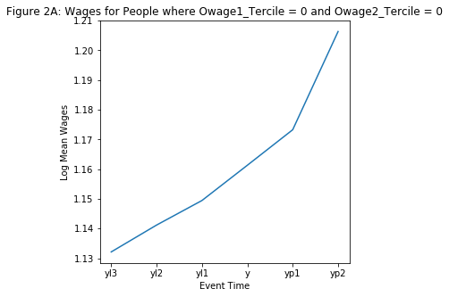

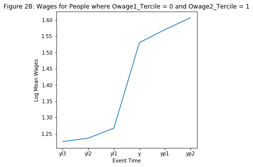

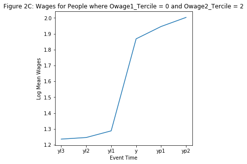

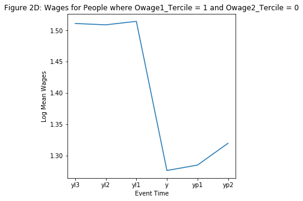

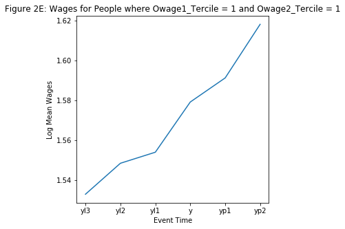

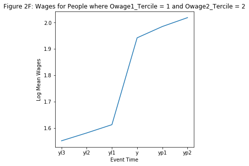

[figure not shown]

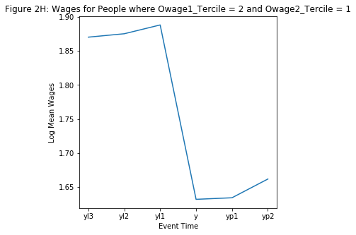

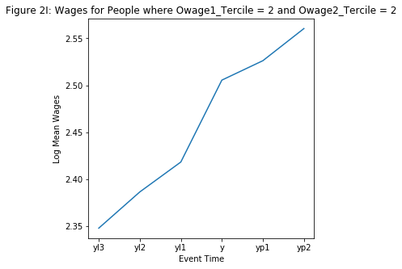

```python
#combo group 0
data0 = dd[dd['combo_groups'] == 0][['yl3', 'yl2', 'yl1', 'y', 'yp1', 'yp2']]
y0 = np.mean(data0)
plt.plot(y0)
plt.title("Figure 2A: Wages for People where Owage1_Tercile = 0 and Owage2_Tercile = 0")
plt.xlabel("Event Time")
plt.ylabel("Log Mean Wages")
plt.figure(figsize = (1, 1))
plt.show()
#combo group 1
data1 = dd[dd['combo_groups'] == 1][['yl3', 'yl2', 'yl1', 'y', 'yp1', 'yp2']]
y1 = np.mean(data1)
plt.plot(y1)
plt.title("Figure 2B: Wages for People where Owage1_Tercile = 0 and Owage2_Tercile = 1")
plt.xlabel("Event Time")
plt.ylabel("Log Mean Wages")
plt.figure(figsize = (1, 1))
plt.show()
#combo group 2
data2 = dd[dd['combo_groups'] == 2][['yl3', 'yl2', 'yl1', 'y', 'yp1', 'yp2']]
y2 = np.mean(data2)
plt.plot(y2)
plt.title("Figure 2C: Wages for People where Owage1_Tercile = 0 and Owage2_Tercile = 2")
plt.xlabel("Event Time")
plt.ylabel("Log Mean Wages")
plt.figure(figsize = (1, 1))
plt.show()
#combo group 3
data3 = dd[dd['combo_groups'] == 3][['yl3', 'yl2', 'yl1', 'y', 'yp1', 'yp2']]
y3 = np.mean(data3)
plt.plot(y3)
plt.title("Figure 2D: Wages for People where Owage1_Tercile = 1 and Owage2_Tercile = 0")
plt.xlabel("Event Time")
plt.ylabel("Log Mean Wages")
plt.figure(figsize = (1, 1))
plt.show()
#combo group 4
data4 = dd[dd['combo_groups'] == 4][['yl3', 'yl2', 'yl1', 'y', 'yp1', 'yp2']]
y4 = np.mean(data4)
plt.plot(y4)
plt.title("Figure 2E: Wages for People where Owage1_Tercile = 1 and Owage2_Tercile = 1")
plt.xlabel("Event Time")
plt.ylabel("Log Mean Wages")
plt.figure(figsize = (1, 1))
plt.show()
#combo group 5
data5 = dd[dd['combo_groups'] == 5][['yl3', 'yl2', 'yl1', 'y', 'yp1', 'yp2']]
y5 = np.mean(data5)
plt.plot(y5)
plt.title("Figure 2F: Wages for People where Owage1_Tercile = 1 and Owage2_Tercile = 2")
plt.xlabel("Event Time")
plt.ylabel("Log Mean Wages")
plt.figure(figsize = (1, 1))
plt.show()
#combo group 6
data6 = dd[dd['combo_groups'] == 0][['yl3', 'yl2', 'yl1', 'y', 'yp1', 'yp2']]
y6 = np.mean(data6)
plt.plot(y6)
plt.title("Figure 2G: Wages for People where Owage1_Tercile = 2 and Owage2_Tercile = 0")
plt.xlabel("Event Time")
plt.ylabel("Log Mean Wages")
plt.figure(figsize = (1, 1))
plt.show()
#combo group 7
data7 = dd[dd['combo_groups'] == 7][['yl3', 'yl2', 'yl1', 'y', 'yp1', 'yp2']]
y7 = np.mean(data7)
plt.plot(y7)
plt.title("Figure 2H: Wages for People where Owage1_Tercile = 2 and Owage2_Tercile = 1")
plt.xlabel("Event Time")
plt.ylabel("Log Mean Wages")
plt.figure(figsize = (1, 1))
plt.show()
#combo group 8
data8 = dd[dd['combo_groups'] == 8][['yl3', 'yl2', 'yl1', 'y', 'yp1', 'yp2']]
y8 = np.mean(data8)
plt.plot(y8)
plt.title("Figure 2I: Wages for People where Owage1_Tercile = 2 and Owage2_Tercile = 2")
plt.xlabel("Event Time")
plt.ylabel("Log Mean Wages")
plt.figure(figsize = (1, 1))
plt.show()
```

Co-worker wages matter because we can see from the above figures that all combinations of co-worker wages for the first job versus second job who either stay in the same tercile or jump to a higher tercile in their second job experience a steady increase in log wages over time. Note that this is not the case for those whose co-workers' wages decrease from first job to second job. This suggests strongly that co-worker wages are important because they indicate how the individual's wages will shift over time. Those who start out in the second tercile will continue experience increased log wages even if they do not explicitly jump terciles. This result is true across all figures above where coworkers' wages stay in the same tercile from first job to second job, or jump to the tercile above from first job to second job.

This strongly suggests that model 2 (omitted variables related to individual propensity towards ambition) is not accurate. If we were to encounter omitted variable bias related to individual skill, we might expect less consistent results than the ones seen in the above figures.

```python
#model5: constant, female dummy, Dwage
dd5 = dd
dd5['Dwage'] = dd['owage2'] - dd['owage1']
dd5 = dd[["female", "Dwage"]]
dd5 = sm.add_constant(dd5)
yvar5 = dd['y']
dd5model = sm.OLS(yvar5, dd5).fit()
```

```python
#model6: constant, quadratic in experience as of period -1, female, Dwage
dd6 = dd
dd6['Dwage'] = dd['owage2'] - dd['owage1']
dd6['exp_quad'] = pow(dd6['exp'] - 1, 4)
dd6 = dd[['exp_quad', 'female', 'Dwage']]
dd6 = sm.add_constant(dd6)
yvar6 = dd['y']
dd6model = sm.OLS(yvar6, dd6).fit()
```

**Note: experience in period -1 is just experience in period 0 minus 1**

```python
#men only
dd7 = dd
dd7['exp_quad'] = pow(dd7['exp'] - 1, 4)
dd7 = dd7[['exp_quad', 'female', 'Dwage']]
maleonly4 = dd7[dd7["female"] == 0][['exp_quad', 'Dwage']]
maleonly4 = sm.add_constant(maleonly4)
yvarmaleonly4 = dd[dd["female"] == 0][['y']]
maleonlymodel4 = sm.OLS(yvarmaleonly4, maleonly4).fit()
```

```python
#female only
dd8 = dd
dd8['exp_quad'] = pow(dd8['exp'] - 1, 4)
dd8 = dd8[['exp_quad', 'female', 'Dwage']]
femaleonly4 = dd8[dd8["female"] == 1][['exp_quad', 'Dwage']]
femaleonly4 = sm.add_constant(femaleonly4)
yvarfemaleonly4 = dd[dd["female"] == 1][['y']]
femaleonlymodel4 = sm.OLS(yvarfemaleonly4, femaleonly4).fit()
```

```python
#Table representation of results
q4results = Stargazer([dd5model, dd6model, femaleonlymodel4, maleonlymodel4])
q4results.custom_columns(["Entire Sample1", "Entire Sample2", "Female Only", "Male Only"], [1,1,1,1])
q4results.title("Table 4: Examining Wage Differences Coworkers for between First and Second Jobs")

HTML(q4results.render_html())
```

Table 4: Examining Wage Differences Coworkers for between First and Second Jobs

|  | *Dependent variable:* |  |  |  |
| --- | --- | --- | --- | --- |
|  | Entire Sample1 | Entire Sample2 | Female Only | Male Only |
|  | (1) | (2) | (3) | (4) |
| Dwage | -0.011 | -0.017 | -0.016 | -0.016 |
|  | (0.016) | (0.016) | (0.025) | (0.02) |
| const | 1.867*** | 1.923*** | 1.74*** | 1.905*** |
|  | (0.006) | (0.007) | (0.01) | (0.008) |
| exp_quad |  | -0.0*** | -0.0*** | -0.0*** |
|  |  | (0.0) | (0.0) | (0.0) |
| female | -0.208*** | -0.211*** |  |  |
|  | (0.01) | (0.01) |  |  |
| Observations | 16969.0 | 16969.0 | 6394.0 | 10575.0 |
| R<sup>2</sup> | 0.025 | 0.036 | 0.03 | 0.006 |
| Adjusted R<sup>2</sup> | 0.024 | 0.036 | 0.029 | 0.005 |
| Residual Std. Error | 0.637(df = 16966.0) | 0.633(df = 16965.0) | 0.614(df = 6391.0) | 0.644(df = 10572.0) |
| F Statistic | 213.298***(df = 2.0; 16966.0) | 213.199***(df = 3.0; 16965.0) | 97.577***(df = 2.0; 6391.0) | 29.406***(df = 2.0; 10572.0) |
| Note: | *p<0.1; **p<0.05; ***p<0.01 |  |  |  |

One way to summarize the two sets of results is to ask: what fraction of the OLS effect of co-worker wages do we see in the first-differenced models? If, for example, the OLS model for males gives a coefficient on coworker wages of 0.66, but the differenced model gives a coefficient of 0.33, then you might conclude that one half of the OLS effect is a causal effect and the other half reflects differences in the unobserved skills of people who tend to work at high-coworker wage jobs.